# Assigment

```python
import pandas as pd
import numpy as np
import seaborn as sns
import matplotlib.pyplot as plt
from sklearn.model_selection import train_test_split
from sklearn.preprocessing import LabelEncoder

# Load Dataset
file_path = "CustomerChurn.csv"  # Update path as needed
df = pd.read_csv("Customer Churn.csv")


# Task 1: Print Summary Statistics
print("Summary Statistics of Dataset:\n", df.describe(include="all"))
df
```

```
Summary Statistics of Dataset:
               ID  Call Failure Complains  Charge Amount  Freq. of use  \
count   3150.000   3150.000000      3150    3150.000000   3150.000000
unique       NaN           NaN         2            NaN           NaN
top          NaN           NaN        no            NaN           NaN
freq         NaN           NaN      2909            NaN           NaN
mean    1575.500      7.627937       NaN     129.882540     69.460635
std      909.471      7.263886       NaN     102.790931     57.413308
min        1.000      0.000000       NaN      20.000000      0.000000
25%      788.250      1.000000       NaN      50.000000     27.000000
50%     1575.500      6.000000       NaN     100.000000     54.000000
75%     2362.750     12.000000       NaN     200.000000     95.000000
max     3150.000     36.000000       NaN     400.000000    255.000000

        Freq. of SMS  Distinct Called Numbers    Age Group      Plan  Status  \
count    3150.000000              3150.000000  3150.000000      3150    3150
unique           NaN                      NaN          NaN         2       2
top              NaN                      NaN          NaN  pre-paid  active
freq             NaN                      NaN          NaN      2905    2368
mean       73.174921                23.509841     2.826032       NaN     NaN
std       112.237560                17.217337     0.892555       NaN     NaN
min         0.000000                 0.000000     1.000000       NaN     NaN
25%         6.000000                10.000000     2.000000       NaN     NaN
50%        21.000000                21.000000     3.000000       NaN     NaN
75%        87.000000                34.000000     3.000000       NaN     NaN
max       522.000000                97.000000     5.000000       NaN     NaN

                Age  Customer Value Churn
count   3150.000000     3150.000000  3150
unique          NaN             NaN     2
top             NaN             NaN   yes
freq            NaN             NaN  2655
mean      30.998413      470.972916   NaN
std        8.831095      517.015433   NaN
min       15.000000        0.000000   NaN
25%       25.000000      113.801250   NaN
50%       30.000000      228.480000   NaN
75%       30.000000      788.388750   NaN
max       55.000000     2165.280000   NaN
```

|  | ID | Call Failure | Complains | Charge Amount | Freq. of use | Freq. of SMS | Distinct Called Numbers | Age Group | Plan | Status | Age | Customer Value | Churn |
| --- | --- | --- | --- | --- | --- | --- | --- | --- | --- | --- | --- | --- | --- |
| 0 | 1 | 3 | no | 100 | 25 | 32 | 11 | 3 | pre-paid | active | 30 | 193.120 | no |
| 1 | 2 | 8 | no | 100 | 65 | 0 | 13 | 2 | pre-paid | active | 25 | 194.400 | yes |
| 2 | 3 | 0 | no | 200 | 0 | 0 | 0 | 2 | pre-paid | not-active | 25 | 0.000 | yes |
| 3 | 4 | 10 | no | 100 | 54 | 327 | 20 | 2 | pre-paid | active | 25 | 1579.140 | yes |
| 4 | 5 | 10 | no | 100 | 60 | 0 | 31 | 1 | pre-paid | active | 15 | 227.865 | yes |
| ... | ... | ... | ... | ... | ... | ... | ... | ... | ... | ... | ... | ... | ... |
| 3145 | 3146 | 0 | no | 100 | 19 | 12 | 9 | 2 | pre-paid | active | 25 | 108.855 | yes |
| 3146 | 3147 | 9 | no | 50 | 134 | 69 | 37 | 1 | post-paid | active | 15 | 711.205 | yes |
| 3147 | 3148 | 5 | no | 100 | 164 | 57 | 35 | 4 | pre-paid | active | 45 | 357.525 | yes |
| 3148 | 3149 | 1 | no | 100 | 38 | 15 | 14 | 3 | pre-paid | active | 30 | 155.800 | yes |
| 3149 | 3150 | 0 | no | 400 | 33 | 199 | 5 | 3 | pre-paid | active | 30 | 953.120 | yes |

3150 rows × 13 columns

```
Class Label Distribution (Churn):
Churn
yes    2655
no      495
Name: count, dtype: int64
```

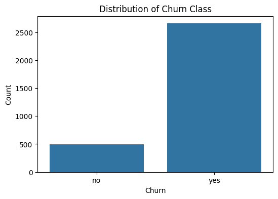

```python
# Task 2: Show Distribution of Churn Class Label
print("\nClass Label Distribution (Churn):")
print(df['Churn'].value_counts())

# Visualize Churn Distribution
plt.figure(figsize=(6, 4))
sns.countplot(x="Churn", data=df)
plt.title("Distribution of Churn Class")
plt.xlabel("Churn")
plt.ylabel("Count")
plt.show()
```

==> Interpretations: Class Distribution (Churn):

Yes: 2,655 instances (approximately 84%). No: 495 instances (approximately 16%). Observation: The dataset is highly imbalanced, with a significant majority of customers classified as churned. This imbalance should be considered when training machine learning models to avoid bias towards the dominant class.

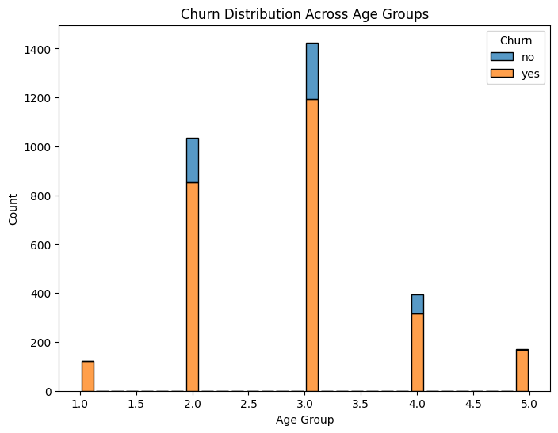

```python
# Task 3: Histogram of Churn per Age Group
plt.figure(figsize=(8, 6))
sns.histplot(data=df, x="Age Group", hue="Churn", multiple="stack", shrink=0.8)
plt.title("Churn Distribution Across Age Groups")
plt.xlabel("Age Group")
plt.ylabel("Count")
plt.show()
```

==> Interpretations: Churn Distribution Across Age Groups:

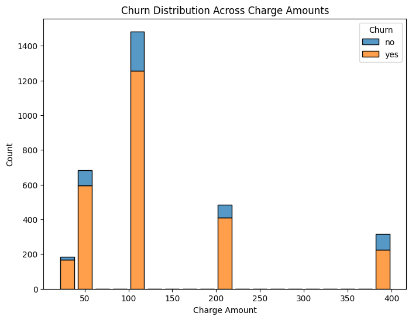

```python
# Task 4: Histogram of Churn per Charge Amount
plt.figure(figsize=(8, 6))
sns.histplot(data=df, x="Charge Amount", hue="Churn", multiple="stack", shrink=0.8)
plt.title("Churn Distribution Across Charge Amounts")
plt.xlabel("Charge Amount")
plt.ylabel("Count")
plt.show()
```

```python
# Task 5: Details of Charge Amount
print("\nCharge Amount Details:")
print(df['Charge Amount'].describe())
```

```
Charge Amount Details:
count    3150.000000
mean      129.882540
std       102.790931
min        20.000000
25%        50.000000
50%       100.000000
75%       200.000000
max       400.000000
Name: Charge Amount, dtype: float64
```

==> Interpretations:

1. Count: 3150 observations indicate a substantial dataset size, sufficient for meaningful analysis.
2. Mean: 129.88 units suggest the typical charge amount is around this value, but variability should be considered.
3. Standard Deviation (Std):

   102.79 units show a high level of variability, indicating significant differences in charge amounts across customers. Minimum and Maximum Values:
4. The range of 20.00 (min) to 400.00 (max) suggests a broad spectrum of charges, from very low to high amounts. ==>Percentiles:

<> 25% (50.00): 25% of the customers are charged less than 50 units. <> 50% (Median, 100.00): Half of the customers are charged less than 100 units, indicating that the distribution is slightly skewed toward higher values (mean > median). <> 75% (200.00): 25% of the customers are charged more than 200 units.

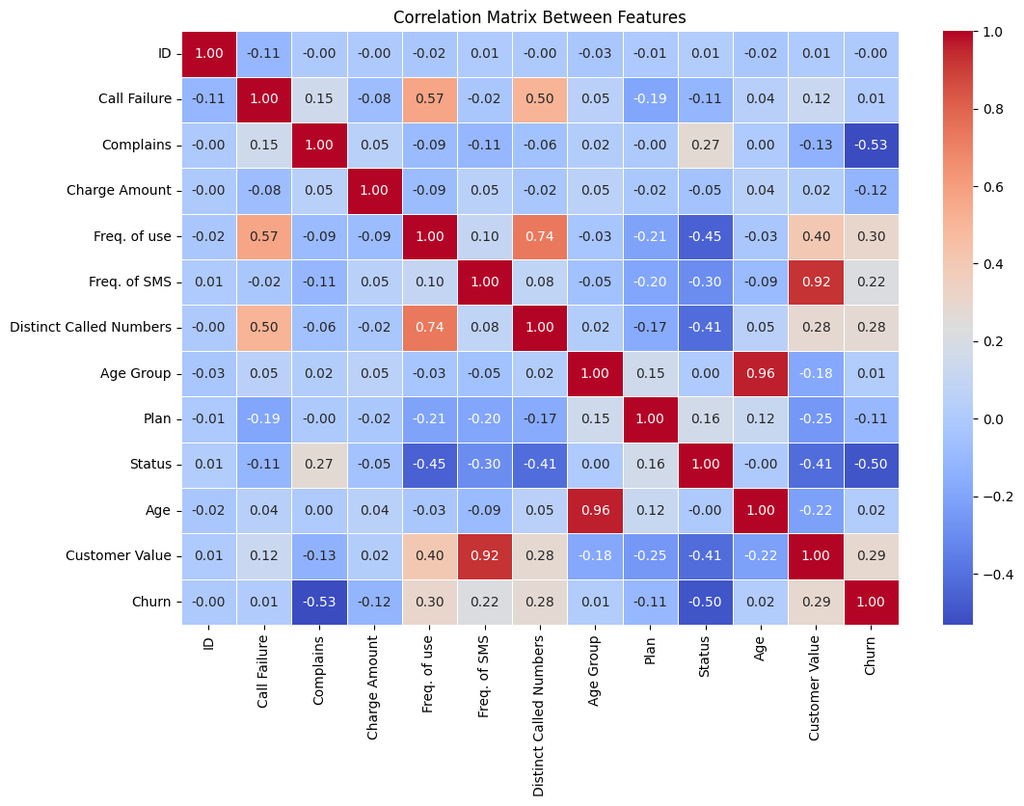

```
                               ID  Call Failure  Complains  Charge Amount  \
ID                       1.000000     -0.108688  -0.002943      -0.000540
Call Failure            -0.108688      1.000000   0.152879      -0.078536
Complains               -0.002943      0.152879   1.000000       0.046231
Charge Amount           -0.000540     -0.078536   0.046231       1.000000
Freq. of use            -0.017680      0.573349  -0.090774      -0.086236
Freq. of SMS             0.006297     -0.022282  -0.111633       0.046735
Distinct Called Numbers -0.003900      0.504058  -0.058199      -0.024186
Age Group               -0.027544      0.050406   0.019976       0.054812
Plan                    -0.006541     -0.192285  -0.001140      -0.017286
Status                   0.012550     -0.114645   0.271405      -0.047464
Age                     -0.021076      0.041758   0.003298       0.043281
Customer Value           0.005464      0.121225  -0.132895       0.021130
Churn                   -0.000263      0.008987  -0.532053      -0.121186

                         Freq. of use  Freq. of SMS  Distinct Called Numbers  \
ID                          -0.017680      0.006297                -0.003900
Call Failure                 0.573349     -0.022282                 0.504058
Complains                   -0.090774     -0.111633                -0.058199
Charge Amount               -0.086236      0.046735                -0.024186
Freq. of use                 1.000000      0.100019                 0.736114
Freq. of SMS                 0.100019      1.000000                 0.079650
Distinct Called Numbers      0.736114      0.079650                 1.000000
Age Group                   -0.032544     -0.053719                 0.020941
Plan                        -0.206452     -0.195686                -0.172079
Status                      -0.454752     -0.296164                -0.413039
Age                         -0.028350     -0.092798                 0.051037
Customer Value               0.401572      0.924877                 0.284807
Churn                        0.303337      0.220754                 0.278867

                         Age Group      Plan    Status       Age  \
ID                       -0.027544 -0.006541  0.012550 -0.021076
Call Failure              0.050406 -0.192285 -0.114645  0.041758
Complains                 0.019976 -0.001140  0.271405  0.003298
Charge Amount             0.054812 -0.017286 -0.047464  0.043281
Freq. of use             -0.032544 -0.206452 -0.454752 -0.028350
Freq. of SMS             -0.053719 -0.195686 -0.296164 -0.092798
Distinct Called Numbers   0.020941 -0.172079 -0.413039  0.051037
Age Group                 1.000000  0.150593  0.002506  0.960758
Plan                      0.150593  1.000000  0.164143  0.119426
Status                    0.002506  0.164143  1.000000 -0.001312
Age                       0.960758  0.119426 -0.001312  1.000000
Customer Value           -0.183481 -0.252298 -0.412990 -0.220362
Churn                     0.014550 -0.105853 -0.498976  0.017705

                         Customer Value     Churn
ID                             0.005464 -0.000263
Call Failure                   0.121225  0.008987
Complains                     -0.132895 -0.532053
Charge Amount                  0.021130 -0.121186
Freq. of use                   0.401572  0.303337
Freq. of SMS                   0.924877  0.220754
Distinct Called Numbers        0.284807  0.278867
Age Group                     -0.183481  0.014550
Plan                          -0.252298 -0.105853
Status                        -0.412990 -0.498976
Age                           -0.220362  0.017705
Customer Value                 1.000000  0.289144
Churn                          0.289144  1.000000
```

```python
from sklearn.preprocessing import LabelEncoder

# Encode Categorical Features to Numeric (e.g., 'Plan', 'Complains', 'Churn', 'Status')
label_encoder = LabelEncoder()
categorical_columns = ['Plan', 'Complains', 'Status', 'Churn']

for col in categorical_columns:
    df[col] = label_encoder.fit_transform(df[col])

# Compute Correlation Matrix
correlation_matrix = df.corr()

# Plot Correlation Matrix Heatmap
plt.figure(figsize=(12, 8))
sns.heatmap(correlation_matrix, annot=True, cmap="coolwarm", fmt=".2f", linewidths=0.5)
plt.title("Correlation Matrix Between Features")
plt.show()
print( df.corr())
```

==> Interpretations:

1. Call Failure: Positive Correlation: ==>Frequency of Use (r=0.573): Higher call failures are associated with frequent usage. Distinct Called Numbers (r=0.504): More unique numbers called increase call failures.

Negative Correlation: Plan (r=−0.192): Certain plans may help reduce call failures. 3. Complaints: Strong Negative Correlation: Churn (r=−0.532): Effectively addressing complaints inversely impacts churn, likely due to successful resolution efforts.

4. Churn: Positive Correlation: Frequency of Use (r=0.303), Customer Value (r=0.289), and Distinct Called Numbers (r=0.278): High-usage and high-value customers may still churn, possibly due to dissatisfaction. Negative Correlation: Complaints (r=−0.532): Handling complaints reduces churn. Status (r=−0.499): Improved customer status helps retain customers.
5. Customer Value: Strong Positive Correlation: Frequency of SMS (r=0.925): High SMS activity significantly contributes to customer value. Moderate Correlation: Frequency of Use (r=0.402): Frequent usage boosts customer value.
6. Age Group and Age: Strong Correlation: (r=0.961): Reflects a natural alignment between age group categories and actual age.
7. Plan: Weak Correlations: Status (r=0.164): Certain plans may slightly improve customer perception or satisfaction.

```python
# Task 7: Split Data into Training (70%) and Test (30%)
# Features and Target
# Drop Redundant or Irrelevant Features
from sklearn.model_selection import train_test_split

# Drop irrelevant or redundant features based on the correlation analysis
features_to_drop = ['ID', 'Age', 'Complains', 'Charge Amount']
df_clean = df.drop(columns=features_to_drop)

# Prepare the dataset
# Assuming 'Customer Value' is the target variable
X = df_clean.drop(columns=['Churn', 'Customer Value'])  # Features (excluding target variable)
y = df_clean['Customer Value']  # Target variable

# Split the data into training (70%) and test (30%) sets
X_train, X_test, y_train, y_test = train_test_split(X, y, test_size=0.3, random_state=42)

# Print out the shape of training and test sets
print("Training Set Shape:", X_train.shape)
print("Test Set Shape:", X_test.shape)
```

```
Training Set Shape: (2205, 7)
Test Set Shape: (945, 7)
```

==> Interpretations:

Regression tasks:

```python
from sklearn.linear_model import LinearRegression
from sklearn.metrics import mean_squared_error, r2_score
X_train, X_test, y_train, y_test = train_test_split(X, y, test_size=0.3, random_state=42)

# Initialize the Linear Regression model
model_lrm1 = LinearRegression()

# Fit the model with training data
model_lrm1.fit(X_train, y_train)

# Predict on test data
y_pred_lrm1 = model_lrm1.predict(X_test)

# Evaluate the model
mse = mean_squared_error(y_test, y_pred_lrm1)
r2 = r2_score(y_test, y_pred_lrm1)

# Print the results
print("Mean Squared Error (MSE) for LRM1:", mse)
print("R-squared (R2) for LRM1:", r2)
```

```
Mean Squared Error (MSE) for LRM1: 7022.47065186014
R-squared (R2) for LRM1: 0.9732179199430433
```

```python
from sklearn.model_selection import train_test_split
from sklearn.linear_model import LinearRegression
from sklearn.metrics import mean_squared_error, r2_score

# Select the 2 most important features and target variable
X_lrm2 = X[['Freq. of SMS', 'Freq. of use']]  # Replace with actual feature names if different
y_lrm2 = y  # Target variable (Customer Value)

# Split the data into training and testing sets
X_train_lrm2, X_test_lrm2, y_train_lrm2, y_test_lrm2 = train_test_split(X_lrm2, y_lrm2, test_size=0.2, random_state=42)

# Initialize the Linear Regression model
model_lrm2 = LinearRegression()

# Fit the model with training data
model_lrm2.fit(X_train_lrm2, y_train_lrm2)

# Predict on test data
y_pred_lrm2 = model_lrm2.predict(X_test_lrm2)

# Evaluate the model
mse_lrm2 = mean_squared_error(y_test_lrm2, y_pred_lrm2)
r2_lrm2 = r2_score(y_test_lrm2, y_pred_lrm2)

# Print the results
print("Mean Squared Error (MSE) for LRM2:", mse_lrm2)
print("R-squared (R2) for LRM2:", r2_lrm2)
```

```
Mean Squared Error (MSE) for LRM2: 11524.89898845864
R-squared (R2) for LRM2: 0.9563971862356679
```

==> Interpretations:

"Freq. of SMS": This feature has a high correlation with "Customer Value" (0.92). "Freq. of use": This feature also has a moderate correlation with "Customer Value" (0.40).

```python
# Select the most important features based on the correlation matrix

X_lrm3 = X[['Freq. of SMS', 'Freq. of use', 'Distinct Called Numbers']]
y_lrm3 = y  # Target variable (Customer Value)

# Split the data into training and test sets for LRM3
X_train_lrm3, X_test_lrm3, y_train_lrm3, y_test_lrm3 = train_test_split(X_lrm3, y_lrm3, test_size=0.3, random_state=42)

# Initialize the Linear Regression model
model_lrm3 = LinearRegression()

# Fit the model with training data
model_lrm3.fit(X_train_lrm3, y_train_lrm3)

# Predict on test data
y_pred_lrm3 = model_lrm3.predict(X_test_lrm3)

# Evaluate the model
mse_lrm3 = mean_squared_error(y_test_lrm3, y_pred_lrm3)
r2_lrm3 = r2_score(y_test_lrm3, y_pred_lrm3)

# Print the results
print("Mean Squared Error (MSE) for LRM3:", mse_lrm3)
print("R-squared (R2) for LRM3:", r2_lrm3)
```

```
Mean Squared Error (MSE) for LRM3: 10923.245932980271
R-squared (R2) for LRM3: 0.9583412645546032
```

==> Interpretations:

"Freq. of SMS": This feature has a high correlation with "Customer Value" (0.92). "Freq. of use": This feature also has a moderate correlation with "Customer Value" (0.40). "Distinct Called Numbers" (0.28): A moderate positive correlation, indicating that customers who call a wider range of numbers are likely to have a higher customer value due to more varied usage.

==> Interpretations:

Performance Metrics Summary

LRM1:

Features Used: Top 2features (Freq. of SMS, Freq. of use) MSE: 11524.89 R²: 0.9563 Observations: A simpler model with slightly reduced predictive power compared to LRM1.

LRM3:

Features Used: Top 3 features (Freq. of SMS, Freq. of use, Distinct Called Numbers) MSE: 10923.25 R²: 0.9583 Observations: Balances simplicity and performance with minimal trade-offs.

Classification tasks:

```
Results:
                   Model  Accuracy  Precision    Recall  F1-Score   ROC/AUC
0  k-Nearest Neighbours  0.921693   0.937046  0.972362  0.954377  0.939897
1           Naive Bayes  0.750265   0.977816  0.719849  0.829233  0.911112
2         Decision Tree  0.921693   0.929762  0.981156  0.954768  0.930167
3   Logistic Regression  0.910053   0.919717  0.978643  0.948265  0.926200
```

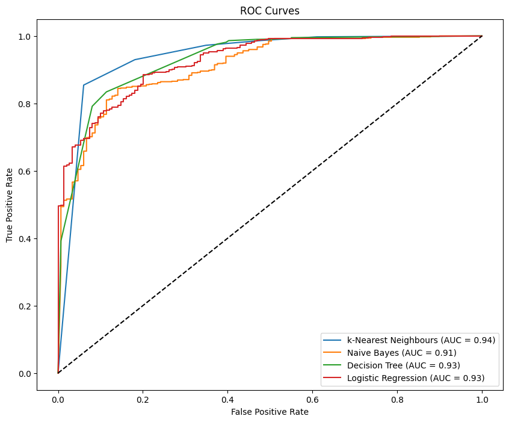

```python
import pandas as pd
import numpy as np
from sklearn.model_selection import train_test_split
from sklearn.preprocessing import LabelEncoder, StandardScaler
from sklearn.metrics import confusion_matrix, classification_report, roc_auc_score, roc_curve
from sklearn.neighbors import KNeighborsClassifier
from sklearn.naive_bayes import GaussianNB
from sklearn.tree import DecisionTreeClassifier
from sklearn.linear_model import LogisticRegression
import matplotlib.pyplot as plt

# Replace categorical column names with actual names of your categorical columns

# Split into training and test sets first

X = df.drop("Churn", axis=1)  # Drop target column, assuming it's 'Churn'
y = df["Churn"]

X_train, X_test, y_train, y_test = train_test_split(X, y, test_size=0.3, random_state=42)

# Encode categorical features
label_encoders = {}
categorical_columns = ["Plan", "Status"]  # Modify these column names based on your data
for col in categorical_columns:
    le = LabelEncoder()
    X_train[col] = le.fit_transform(X_train[col])
    X_test[col] = le.transform(X_test[col])  # Use the same encoder for test data
    label_encoders[col] = le

# Scale numerical features
scaler = StandardScaler()
X_train = scaler.fit_transform(X_train.select_dtypes(include=[np.number]))
X_test = scaler.transform(X_test.select_dtypes(include=[np.number]))

# Initialize classifiers
classifiers = {
    "k-Nearest Neighbours": KNeighborsClassifier(n_neighbors=5),
    "Naive Bayes": GaussianNB(),
    "Decision Tree": DecisionTreeClassifier(max_depth=5, random_state=42),
    "Logistic Regression": LogisticRegression(random_state=42),
}

# Evaluate classifiers
results = []
for name, clf in classifiers.items():
    clf.fit(X_train, y_train)
    y_pred = clf.predict(X_test)
    y_prob = clf.predict_proba(X_test)[:, 1] if hasattr(clf, "predict_proba") else y_pred

    # Metrics
    cm = confusion_matrix(y_test, y_pred)
    roc_auc = roc_auc_score(y_test, y_prob) if len(np.unique(y_test)) > 1 else 0.0
    report = classification_report(y_test, y_pred, output_dict=True)

    results.append({
        "Model": name,
        "Accuracy": report["accuracy"],
        "Precision": report["1"]["precision"] if "1" in report else 0.0,
        "Recall": report["1"]["recall"] if "1" in report else 0.0,
        "F1-Score": report["1"]["f1-score"] if "1" in report else 0.0,
        "ROC/AUC": roc_auc,
        "Confusion Matrix": cm,
    })

# Display results in a table
results_df = pd.DataFrame(results).drop(columns=["Confusion Matrix"])
print("Results:\n", results_df)

# Plot ROC curves
plt.figure(figsize=(10, 8))
for name, clf in classifiers.items():
    if hasattr(clf, "predict_proba"):
        y_prob = clf.predict_proba(X_test)[:, 1]
        fpr, tpr, _ = roc_curve(y_test, y_prob)
        plt.plot(fpr, tpr, label=f"{name} (AUC = {roc_auc_score(y_test, y_prob):.2f})")

plt.plot([0, 1], [0, 1], "k--")
plt.xlabel("False Positive Rate")
plt.ylabel("True Positive Rate")
plt.title("ROC Curves")
plt.legend()
plt.show()
```

1. k-Nearest Neighbours (k-NN) Metrics:

Accuracy: 0.9217 0.9217 (92.17%) The model correctly predicts 92.17% of all instances. Precision: 0.9370 0.9370 (93.70%) Among all predicted positives, 93.70% are actual positives. Recall: 0.9724 0.9724 (97.24%) The model identifies 97.24% of actual positive instances. F1-Score: 0.9544 0.9544 (95.44%) Shows a balance between precision and recall, indicating strong performance. ROC/AUC: 0.9399 0.9399 (93.99%) Indicates excellent discrimination between classes.

==> Interpretation: The k-NN model demonstrates high accuracy, precision, and recall, making it reliable for identifying positive cases. It’s particularly suitable when missing positives (false negatives) is critical, such as in medical diagnostics or fraud detection.

2. Naive Bayes Metrics:

Accuracy: 0.7503 0.7503 (75.03%) Correctly predicts 75.03% of all instances, which is significantly lower than other models. Precision: 0.9778 0.9778 (97.78%) Exceptionally high precision, meaning the model rarely predicts false positives. Recall: 0.7198 0.7198 (71.98%) Relatively low recall, indicating it misses many actual positive cases. F1-Score: 0.8292 0.8292 (82.92%) Reflects an imbalance between precision and recall. ROC/AUC: 0.9111 0.9111 (91.11%) Good but not as high as k-NN.

==> Interpretation: Naive Bayes excels in precision, making it a good choice for applications where minimizing false positives is more critical than identifying all positives. However, its low recall may make it unsuitable for cases where missing true positives is costly, such as disease screening or fraud detection.

3. Decision Tree Metrics:

Accuracy: 0.9217 0.9217 (92.17%) The model predicts 92.17% of instances correctly. Precision: 0.9298 0.9298 (92.98%) Slightly lower than k-NN but still high, indicating reliable positive predictions. Recall: 0.9812 0.9812 (98.12%) Excellent ability to identify actual positive cases, slightly higher than k-NN. F1-Score: 0.9548 0.9548 (95.48%) Shows a strong balance between precision and recall. ROC/AUC: 0.9302 0.9302 (93.02%) Indicates good class discrimination but slightly lower than k-NN.

==> Interpretation: The Decision Tree performs similarly to k-NN with comparable accuracy, recall, and F1-Score. Its slightly lower precision and ROC/AUC compared to k-NN suggest it’s also reliable but may have a slightly higher rate of false positives. This model is versatile and can adapt well to different datasets with proper tuning.

==> Interpretation: Logistic Regression is a robust model with balanced performance, although it slightly underperforms compared to k-NN and Decision Tree. It’s suitable for applications requiring consistent and interpretable results, such as customer churn prediction or credit risk analysis.